# 01_03_Bankruptcy_Risk_Prediction04_withkaggle_V10

### 다른 대출 상태와 전화소유여부는 파산여부는 어떤 관계가 있을까?

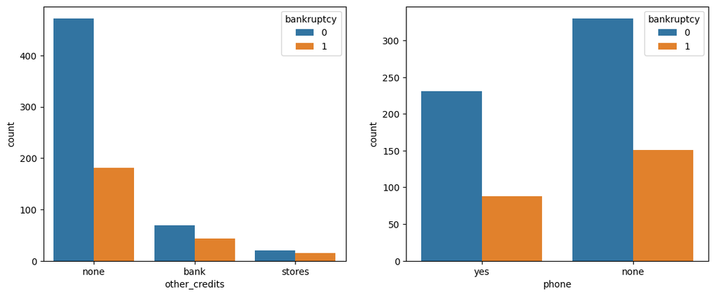

```python
plt.figure(figsize=(13,5) )
plt.subplot(1,2,1)
sns.countplot(x="other_credits", hue="bankruptcy",  data=train)


plt.subplot(1,2,2)
sns.countplot(x="phone", hue="bankruptcy", data=train)
```

### 이민자여부, 주거형태는 파산여부는 어떤 관계가 있을까?

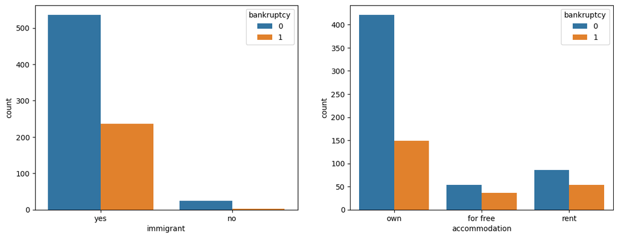

```python
plt.figure(figsize=(14,5) )
plt.subplot(1,2,1)
sns.countplot(x="immigrant", hue="bankruptcy",  data=train)


plt.subplot(1,2,2)
sns.countplot(x="accommodation", hue="bankruptcy", data=train)
```

```python
train.columns
```

```
Index(['id', 'sum', 'term', 'payment', 'guarantees', 'reason', 'credits',
       'other_credits', 'credit_report', 'marital_status', 'age', 'employment',
       'qualification', 'immigrant', 'residence_since', 'accommodation',
       'estate', 'savings', 'dependents', 'phone', 'status', 'bankruptcy'],
      dtype='object')
```

```python
train.head()
```

|  | id | sum | term | payment | guarantees | reason | credits | other_credits | credit_report | marital_status | age | employment | qualification | immigrant | residence_since | accommodation | estate | savings | dependents | phone | status | bankruptcy |
| --- | --- | --- | --- | --- | --- | --- | --- | --- | --- | --- | --- | --- | --- | --- | --- | --- | --- | --- | --- | --- | --- | --- |
| 0 | 0 | 1169 | 6 | 4 | none | television or radio | 2 | none | critical account or other credits existing(not... | male single | 67 | 7+ y. | skilled employee | yes | 4 | own | real estate | unknown or no savings account | 1 | yes | less-than 0 cu | 0 |
| 1 | 1 | 5951 | 48 | 2 | none | television or radio | 1 | none | existing credits paid back duly till now | female divorced or separated or married | 22 | 1 to 4 y. | skilled employee | yes | 2 | own | real estate | less-than 100 cu | 1 | none | 0 to 200 cu | 1 |
| 2 | 2 | 2096 | 12 | 2 | none | education | 1 | none | critical account or other credits existing(not... | male single | 49 | 4 to 7 y. | unskilled resident | yes | 3 | own | real estate | less-than 100 cu | 2 | none | no checking account | 0 |
| 3 | 3 | 7882 | 42 | 2 | guarantor | furniture or equipment | 1 | none | existing credits paid back duly till now | male single | 45 | 4 to 7 y. | skilled employee | yes | 4 | for free | building society savings agreement or life ins... | less-than 100 cu | 2 | none | less-than 0 cu | 0 |
| 4 | 4 | 4870 | 24 | 3 | none | new car | 2 | none | delay in paying off in the past | male single | 53 | 1 to 4 y. | skilled employee | yes | 4 | for free | unknown or no property | less-than 100 cu | 2 | none | less-than 0 cu | 1 |

### 04 데이터 전처리 및 데이터 나누기

목차로 이동하기

```python
print( train.guarantees.unique() )
print( train.reason.unique()  )
print( train.other_credits.unique()  )
print( train.marital_status.unique()  )
print( train.qualification.unique()  )
print( train.immigrant.unique()  )
print( train.accommodation.unique()  )
print( train.estate.unique()  )
print( train.phone.unique()  )
```

```
['none' 'guarantor' 'co-applicant']
['television or radio' 'education' 'furniture or equipment' 'new car'
 'used car' 'business' 'household appliances' 'repairs' 'other'
 'requalification']
['none' 'bank' 'stores']
['male single' 'female divorced or separated or married'
 'male divorced or separated' 'male married or widowed']
['skilled employee' 'unskilled resident'
 'management or self-employed or highly qualified employee'
 'unemployed or unskilled non-resident']
['yes' 'no']
['own' 'for free' 'rent']
['real estate' 'building society savings agreement or life insurance'
 'unknown or no property' 'car or other']
['yes' 'none']
```

```python
### 데이터 전처리
sub = pd.read_csv("/kaggle/input/bankruptcy-risk-prediction/submission_example.csv")
train = pd.read_csv("/kaggle/input/bankruptcy-risk-prediction/train.csv")
test = pd.read_csv("/kaggle/input/bankruptcy-risk-prediction/test.csv")

train.shape, test.shape, sub.shape
```

```
((800, 22), (200, 21), (200, 2))
```

### 각 컬럼별 데이터 값들 확인하기

```python
### 전체 컬럼 unique() 확인하기
### 범주형 - 범주가 50개 이하만 출력하기
def columns_print(dataset):
    for one in dataset.columns:
        # print(one)
        col_length = len( dataset[one].unique() )
        if col_length <= 50:
            print("colname : ", one)
            print(dataset[one].unique())

columns_print(train)
```

```
colname :  term
[ 6 48 12 42 24 36 30 15  9 10  7 60 18 45 11 27  8 54 20 14 33 21 16  4
 47 13 22 39 28  5 26 72 40]
colname :  payment
[4 2 3 1]
colname :  guarantees
['none' 'guarantor' 'co-applicant']
colname :  reason
['television or radio' 'education' 'furniture or equipment' 'new car'
 'used car' 'business' 'household appliances' 'repairs' 'other'
 'requalification']
colname :  credits
[2 1 3 4]
colname :  other_credits
['none' 'bank' 'stores']
colname :  credit_report
['critical account or other credits existing(not at this bank)'
 'existing credits paid back duly till now'
 'delay in paying off in the past' 'no credits or all paid'
 'all credits at this bank paid back duly']
colname :  marital_status
['male single' 'female divorced or separated or married'
 'male divorced or separated' 'male married or widowed']
colname :  employment
['7+ y.' '1 to 4 y.' '4 to 7 y.' 'unemployed' 'less-than 1 y.']
colname :  qualification
['skilled employee' 'unskilled resident'
 'management or self-employed or highly qualified employee'
 'unemployed or unskilled non-resident']
colname :  immigrant
['yes' 'no']
colname :  residence_since
[4 2 3 1]
colname :  accommodation
['own' 'for free' 'rent']
colname :  estate
['real estate' 'building society savings agreement or life insurance'
 'unknown or no property' 'car or other']
colname :  savings
['unknown or no savings account' 'less-than 100 cu' '500 to 1000 cu'
 'greater-than 1000 cu' '100 to 500 cu']
colname :  dependents
[1 2]
colname :  phone
['yes' 'none']
colname :  status
['less-than 0 cu' '0 to 200 cu' 'no checking account'
 'greater-than 200 cu or salary assignments for at least 1 year']
colname :  bankruptcy
[0 1]
```

```python
### 인코딩 map 내용 만들기
def map_con(dataset, col_names):
    dict_map = {}
    cnt = 0
    unique_value = dataset[col_names].unique()
    print( unique_value )

    for one in unique_value:
        # print(one)
        dict_map[one] = cnt
        cnt += 1
    # print(dict_map)
    return dict_map

map_con(train, "reason")
```

```
['television or radio' 'education' 'furniture or equipment' 'new car'
 'used car' 'business' 'household appliances' 'repairs' 'other'
 'requalification']
```

```
{'television or radio': 0,
 'education': 1,
 'furniture or equipment': 2,
 'new car': 3,
 'used car': 4,
 'business': 5,
 'household appliances': 6,
 'repairs': 7,
 'other': 8,
 'requalification': 9}
```

```python
columns_print(train)
```

```
colname :  term
[ 6 48 12 42 24 36 30 15  9 10  7 60 18 45 11 27  8 54 20 14 33 21 16  4
 47 13 22 39 28  5 26 72 40]
colname :  payment
[4 2 3 1]
colname :  guarantees
['none' 'guarantor' 'co-applicant']
colname :  reason
['television or radio' 'education' 'furniture or equipment' 'new car'
 'used car' 'business' 'household appliances' 'repairs' 'other'
 'requalification']
colname :  credits
[2 1 3 4]
colname :  other_credits
['none' 'bank' 'stores']
colname :  credit_report
['critical account or other credits existing(not at this bank)'
 'existing credits paid back duly till now'
 'delay in paying off in the past' 'no credits or all paid'
 'all credits at this bank paid back duly']
colname :  marital_status
['male single' 'female divorced or separated or married'
 'male divorced or separated' 'male married or widowed']
colname :  employment
['7+ y.' '1 to 4 y.' '4 to 7 y.' 'unemployed' 'less-than 1 y.']
colname :  qualification
['skilled employee' 'unskilled resident'
 'management or self-employed or highly qualified employee'
 'unemployed or unskilled non-resident']
colname :  immigrant
['yes' 'no']
colname :  residence_since
[4 2 3 1]
colname :  accommodation
['own' 'for free' 'rent']
colname :  estate
['real estate' 'building society savings agreement or life insurance'
 'unknown or no property' 'car or other']
colname :  savings
['unknown or no savings account' 'less-than 100 cu' '500 to 1000 cu'
 'greater-than 1000 cu' '100 to 500 cu']
colname :  dependents
[1 2]
colname :  phone
['yes' 'none']
colname :  status
['less-than 0 cu' '0 to 200 cu' 'no checking account'
 'greater-than 200 cu or salary assignments for at least 1 year']
colname :  bankruptcy
[0 1]
```

### 데이터 전처리 - 범주형 문자열을 숫자로 변경

- 같은 내용을 두 번 실행할 경우, 셀의 실행 결과는 우리가 예상하는 결과값이 보여지지 않을 수 있다.

```python
# 라벨 인코딩
train['guarantees'] = train.guarantees.map( {'none':0, 'guarantor':1, 'co-applicant':2} )
train.guarantees.unique()
```

```
array([0, 1, 2])
```

```python
# 라벨 인코딩
# 문자를 숫자로 변경
print(train.reason.unique())
reason_dict = map_con(train, "reason")
print(reason_dict)
```

```
['television or radio' 'education' 'furniture or equipment' 'new car'
 'used car' 'business' 'household appliances' 'repairs' 'other'
 'requalification']
['television or radio' 'education' 'furniture or equipment' 'new car'
 'used car' 'business' 'household appliances' 'repairs' 'other'
 'requalification']
{'television or radio': 0, 'education': 1, 'furniture or equipment': 2, 'new car': 3, 'used car': 4, 'business': 5, 'household appliances': 6, 'repairs': 7, 'other': 8, 'requalification': 9}
```

```python
train['reason'] = train.reason.map( {'television or radio': 0,
                        'education': 1, 'furniture or equipment': 2, 'new car': 3,
                        'used car': 4, 'business': 5, 'household appliances': 6,
                        'repairs': 7, 'other': 8, 'requalification': 9} )
train.reason.unique()
```

```
array([0, 1, 2, 3, 4, 5, 6, 7, 8, 9])
```

```python
#print(train['other_credits'].unique())
dat_dict = map_con(train, "other_credits")
#print(reason_dict)
train['other_credits'] = train['other_credits'].map( dat_dict )
train['other_credits'].unique()
```

```
['none' 'bank' 'stores']
```

```
array([0, 1, 2])
```

### test 데이터 셋 변환

- guarantees, reason, other_credits

```python
test['guarantees'] = test.guarantees.map( {'none':0, 'guarantor':1, 'co-applicant':2} )
test.guarantees.unique()

reason_dict = map_con(test, "reason")
print(reason_dict)
test['reason'] = test.reason.map( reason_dict )
test.reason.unique()
```

```
['education' 'television or radio' 'furniture or equipment' 'new car'
 'used car' 'business' 'household appliances' 'other' 'repairs'
 'requalification']
{'education': 0, 'television or radio': 1, 'furniture or equipment': 2, 'new car': 3, 'used car': 4, 'business': 5, 'household appliances': 6, 'other': 7, 'repairs': 8, 'requalification': 9}
```

```
array([0, 1, 2, 3, 4, 5, 6, 7, 8, 9])
```

```python
dat_dict = map_con(test, "other_credits")
#print(reason_dict)
test['other_credits'] = test['other_credits'].map( dat_dict )
test['other_credits'].unique()
```

```
['none' 'bank' 'stores']
```

```
array([0, 1, 2])
```

```python
#  employment, qualification, immigrant, accommodation, savings, phone
```

```python
dat_dict = map_con(train, "credit_report")
train['credit_report'] = train['credit_report'].map( dat_dict )
train['credit_report'].unique()

dat_dict = map_con(train, "marital_status")
train['marital_status'] = train['marital_status'].map( dat_dict )
train['marital_status'].unique()

dat_dict = map_con(train, "employment")
train['employment'] = train['employment'].map( dat_dict )

dat_dict = map_con(train, "qualification")
train['qualification'] = train['qualification'].map( dat_dict )

dat_dict = map_con(train, "immigrant")
train['immigrant'] = train['immigrant'].map( dat_dict )

dat_dict = map_con(train, "accommodation")
train['accommodation'] = train['accommodation'].map( dat_dict )

dat_dict = map_con(train, "savings")
train['savings'] = train['savings'].map( dat_dict )

dat_dict = map_con(train, "phone")
train['phone'] = train['phone'].map( dat_dict )

dat_dict = map_con(train, "estate")
train['estate'] = train['estate'].map( dat_dict )

dat_dict = map_con(train, "credit_report")
train['credit_report'] = train['credit_report'].map( dat_dict )

dat_dict = map_con(train, "status")
train['status'] = train['status'].map( dat_dict )

train.head()
```

```
['critical account or other credits existing(not at this bank)'
 'existing credits paid back duly till now'
 'delay in paying off in the past' 'no credits or all paid'
 'all credits at this bank paid back duly']
['male single' 'female divorced or separated or married'
 'male divorced or separated' 'male married or widowed']
['7+ y.' '1 to 4 y.' '4 to 7 y.' 'unemployed' 'less-than 1 y.']
['skilled employee' 'unskilled resident'
 'management or self-employed or highly qualified employee'
 'unemployed or unskilled non-resident']
['yes' 'no']
['own' 'for free' 'rent']
['unknown or no savings account' 'less-than 100 cu' '500 to 1000 cu'
 'greater-than 1000 cu' '100 to 500 cu']
['yes' 'none']
['real estate' 'building society savings agreement or life insurance'
 'unknown or no property' 'car or other']
[0 1 2 3 4]
['less-than 0 cu' '0 to 200 cu' 'no checking account'
 'greater-than 200 cu or salary assignments for at least 1 year']
```

|  | id | sum | term | payment | guarantees | reason | credits | other_credits | credit_report | marital_status | age | employment | qualification | immigrant | residence_since | accommodation | estate | savings | dependents | phone | status | bankruptcy |
| --- | --- | --- | --- | --- | --- | --- | --- | --- | --- | --- | --- | --- | --- | --- | --- | --- | --- | --- | --- | --- | --- | --- |
| 0 | 0 | 1169 | 6 | 4 | 0 | 0 | 2 | 0 | 0 | 0 | 67 | 0 | 0 | 0 | 4 | 0 | 0 | 0 | 1 | 0 | 0 | 0 |
| 1 | 1 | 5951 | 48 | 2 | 0 | 0 | 1 | 0 | 1 | 1 | 22 | 1 | 0 | 0 | 2 | 0 | 0 | 1 | 1 | 1 | 1 | 1 |
| 2 | 2 | 2096 | 12 | 2 | 0 | 1 | 1 | 0 | 0 | 0 | 49 | 2 | 1 | 0 | 3 | 0 | 0 | 1 | 2 | 1 | 2 | 0 |
| 3 | 3 | 7882 | 42 | 2 | 1 | 2 | 1 | 0 | 1 | 0 | 45 | 2 | 0 | 0 | 4 | 1 | 1 | 1 | 2 | 1 | 0 | 0 |
| 4 | 4 | 4870 | 24 | 3 | 0 | 3 | 2 | 0 | 2 | 0 | 53 | 1 | 0 | 0 | 4 | 1 | 2 | 1 | 2 | 1 | 0 | 1 |

```python
dat_dict = map_con(test, "credit_report")
test['credit_report'] = test['credit_report'].map( dat_dict )
test['credit_report'].unique()

dat_dict = map_con(test, "marital_status")
test['marital_status'] = test['marital_status'].map( dat_dict )
test['marital_status'].unique()

dat_dict = map_con(test, "employment")
test['employment'] = test['employment'].map( dat_dict )

dat_dict = map_con(test, "qualification")
test['qualification'] = test['qualification'].map( dat_dict )

dat_dict = map_con(test, "immigrant")
test['immigrant'] = test['immigrant'].map( dat_dict )

dat_dict = map_con(test, "accommodation")
test['accommodation'] = test['accommodation'].map( dat_dict )

dat_dict = map_con(test, "savings")
test['savings'] = test['savings'].map( dat_dict )

dat_dict = map_con(test, "phone")
test['phone'] = test['phone'].map( dat_dict )

dat_dict = map_con(test, "estate")
test['estate'] = test['estate'].map( dat_dict )

dat_dict = map_con(test, "credit_report")
test['credit_report'] = test['credit_report'].map( dat_dict )

dat_dict = map_con(test, "status")
test['status'] = test['status'].map( dat_dict )

test.head()
```

```
['critical account or other credits existing(not at this bank)'
 'existing credits paid back duly till now'
 'all credits at this bank paid back duly' 'no credits or all paid'
 'delay in paying off in the past']
['male single' 'female divorced or separated or married'
 'male married or widowed' 'male divorced or separated']
['7+ y.' 'unemployed' '4 to 7 y.' 'less-than 1 y.' '1 to 4 y.']
['skilled employee' 'unskilled resident'
 'unemployed or unskilled non-resident'
 'management or self-employed or highly qualified employee']
['yes' 'no']
['for free' 'rent' 'own']
['less-than 100 cu' 'unknown or no savings account' '500 to 1000 cu'
 '100 to 500 cu' 'greater-than 1000 cu']
['none' 'yes']
['unknown or no property' 'real estate'
 'building society savings agreement or life insurance' 'car or other']
[0 1 2 3 4]
['no checking account' '0 to 200 cu' 'less-than 0 cu'
 'greater-than 200 cu or salary assignments for at least 1 year']
```

|  | id | sum | term | payment | guarantees | reason | credits | other_credits | credit_report | marital_status | age | employment | qualification | immigrant | residence_since | accommodation | estate | savings | dependents | phone | status |
| --- | --- | --- | --- | --- | --- | --- | --- | --- | --- | --- | --- | --- | --- | --- | --- | --- | --- | --- | --- | --- | --- |
| 0 | 800 | 1597 | 24 | 4 | 0 | 0 | 2 | 0 | 0 | 0 | 54 | 0 | 0 | 0 | 4 | 0 | 0 | 0 | 2 | 0 | 0 |
| 1 | 801 | 1795 | 18 | 3 | 1 | 1 | 2 | 1 | 0 | 1 | 48 | 0 | 1 | 0 | 4 | 1 | 1 | 0 | 1 | 1 | 1 |
| 2 | 802 | 4272 | 20 | 1 | 0 | 2 | 2 | 0 | 0 | 1 | 24 | 0 | 0 | 0 | 4 | 2 | 2 | 0 | 1 | 0 | 2 |
| 3 | 803 | 976 | 12 | 4 | 0 | 1 | 2 | 0 | 0 | 0 | 35 | 0 | 0 | 0 | 4 | 2 | 3 | 1 | 1 | 0 | 0 |
| 4 | 804 | 7472 | 12 | 1 | 0 | 3 | 1 | 0 | 1 | 1 | 24 | 1 | 2 | 0 | 2 | 1 | 1 | 1 | 1 | 0 | 1 |

```python
train.columns
```

```
Index(['id', 'sum', 'term', 'payment', 'guarantees', 'reason', 'credits',
       'other_credits', 'credit_report', 'marital_status', 'age', 'employment',
       'qualification', 'immigrant', 'residence_since', 'accommodation',
       'estate', 'savings', 'dependents', 'phone', 'status', 'bankruptcy'],
      dtype='object')
```

### 변수별 상관관계를 히트맵과 상관계수를 통해 확인

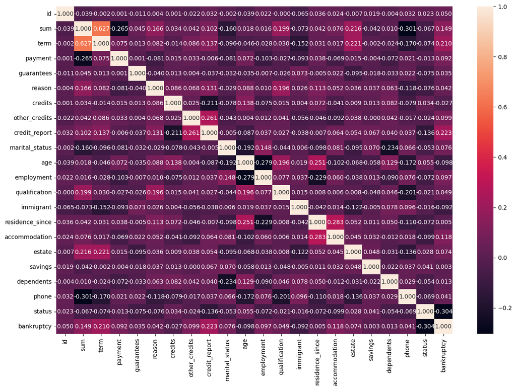

```python
plt.figure(figsize=(15,10))
sns.heatmap(train.corr(), annot=True, fmt=".3f")
```

### 데이터 나누기

- 예측을 위해 사용할 변수 선택하기
- 예측하고자 하는 y값을 선택하기
- 학습용, 테스트용 데이터 셋으로 나누기
- 입력(X)와 출력(y)로 나누기

```python
#  변경2 : 0.05 이하 제외 'guarantees', 'credits', 'qualification', 'residence_since', 'savings', 'dependents', 'phone',
sel = ['sum', 'term', 'payment', 'reason', 'other_credits', 'credit_report',
       'marital_status', 'age', 'employment', 'immigrant',  'accommodation',
       'estate', 'status']

X = train[sel]
y = train['bankruptcy']

last_test = test[sel]

X_train, X_test, y_train, y_test = train_test_split(X, y,
                                                   test_size=0.3,
                                                   random_state = 0)
```

### 05 머신러닝 모델 구축/학습/평가

목차로 이동하기

```python
from sklearn.neighbors import KNeighborsClassifier
from sklearn.tree import DecisionTreeClassifier
from sklearn.ensemble import RandomForestClassifier
import xgboost as xgb
```

### 모델 구축 및 학습, 평가

- KNN
- DecisionTree(의사결정트리)
- RandonForest(랜덤포레스트)
- XGBoost
- model.score() 함수를 이용하여 모델를 평가할 수 있음.
- 여기에서 model.score()는 모델이 예측의 정확도가 어느정도 되는가를 나타낸다. 0.95의 경우 95%의 정확도

```python
model1 = KNeighborsClassifier()
model1.fit(X_train, y_train)
print("model1 학습용 정확도 : ", model1.score(X_train,y_train) )
print("model1 테스트용 정확도 : ", model1.score(X_test,y_test) )
print()

model2 = DecisionTreeClassifier(max_depth=3, random_state=0)
model2.fit(X_train, y_train)
print("model2 학습용 정확도 : ", model2.score(X_train,y_train) )
print("model2 테스트용 정확도 : ", model2.score(X_test,y_test) )
print()

model3 = RandomForestClassifier(max_depth=5, random_state=0)
model3.fit(X_train, y_train)
print("model3 학습용 정확도 : ", model3.score(X_train,y_train) )
print("model3 테스트용 정확도 : ", model3.score(X_test,y_test) )
print()

model4 = xgb.XGBClassifier(colsample_bytree = 0.2, # 각나무마다 사용하는 feature 비율
                           learning_rate = 0.05,
                           max_depth = 3,
                           alpha = 0.1,
                           n_estimators = 1000)

model4.fit(X_train, y_train)
print("model4 학습용 정확도 : ", model4.score(X_train,y_train) )
print("model5 테스트용 정확도 : ", model4.score(X_test,y_test) )
print()
```

```
model1 학습용 정확도 :  0.7517857142857143
model1 테스트용 정확도 :  0.6666666666666666

model2 학습용 정확도 :  0.7732142857142857
model2 테스트용 정확도 :  0.7083333333333334

model3 학습용 정확도 :  0.8285714285714286
model3 테스트용 정확도 :  0.725

model4 학습용 정확도 :  0.9375
model5 테스트용 정확도 :  0.7375
```

### 가장 좋은 모델을 선택

```python
model3 = RandomForestClassifier(max_depth=5, random_state=0)
model3.fit(X_train, y_train)
```

```
RandomForestClassifier(max_depth=5, random_state=0)
```

```python
model4 = xgb.XGBClassifier(colsample_bytree = 0.2, # 각나무마다 사용하는 feature 비율
                           learning_rate = 0.05,
                           max_depth = 3,
                           alpha = 0.1,
                           n_estimators = 1000)
model4.fit(X_train, y_train)
```

```
XGBClassifier(alpha=0.1, base_score=None, booster=None, callbacks=None,
              colsample_bylevel=None, colsample_bynode=None,
              colsample_bytree=0.2, device=None, early_stopping_rounds=None,
              enable_categorical=False, eval_metric=None, feature_types=None,
              gamma=None, grow_policy=None, importance_type=None,
              interaction_constraints=None, learning_rate=0.05, max_bin=None,
              max_cat_threshold=None, max_cat_to_onehot=None,
              max_delta_step=None, max_depth=3, max_leaves=None,
              min_child_weight=None, missing=nan, monotone_constraints=None,
              multi_strategy=None, n_estimators=1000, n_jobs=None,
              num_parallel_tree=None, ...)
```

### 예측을 할때, 확률로 예측해야 한다면 predict_proba() 함수 이용하여 확률 예측 가능

```python
y_pred=model4.predict_proba(last_test)
y_pred
```

```
array([[0.72907174, 0.27092826],
       [0.6507627 , 0.34923732],
       [0.9398224 , 0.06017762],
       [0.43901914, 0.56098086],
       [0.7172885 , 0.28271154],
       [0.8583744 , 0.14162557],
       [0.8928971 , 0.10710287],
       [0.7128705 , 0.2871295 ],
       [0.79603755, 0.20396242],
       [0.45203513, 0.5479649 ],
       [0.43083948, 0.5691605 ],
       [0.75797135, 0.24202864],
       [0.9880464 , 0.01195362],
       [0.3486606 , 0.6513394 ],
       [0.9625053 , 0.03749474],
       [0.05601865, 0.94398135],
       [0.7575426 , 0.24245737],
       [0.9079186 , 0.09208142],
       [0.24266607, 0.75733393],
       [0.7496728 , 0.25032723],
       [0.25798196, 0.74201804],
       [0.7048456 , 0.2951544 ],
       [0.6376219 , 0.36237815],
       [0.892068  , 0.107932  ],
       [0.66136587, 0.33863416],
       [0.49605894, 0.50394106],
       [0.88621813, 0.11378188],
       [0.3379503 , 0.6620497 ],
       [0.98128074, 0.01871928],
       [0.1536482 , 0.8463518 ],
       [0.11175066, 0.88824934],
       [0.34582537, 0.6541746 ],
       [0.36688185, 0.63311815],
       [0.5192131 , 0.48078695],
       [0.95318204, 0.04681797],
       [0.34635592, 0.6536441 ],
       [0.02592844, 0.97407156],
       [0.8954129 , 0.10458711],
       [0.9968895 , 0.00311052],
       [0.4735453 , 0.5264547 ],
```

[output cut: 145 more lines]

```
       [0.8684711 , 0.13152891],
       [0.3914917 , 0.6085083 ],
       [0.8978692 , 0.10213074],
       [0.98815304, 0.01184694],
       [0.6575978 , 0.34240222],
       [0.7557153 , 0.2442847 ],
       [0.22057396, 0.77942604],
       [0.8961587 , 0.10384128],
       [0.88218445, 0.11781555],
       [0.62537444, 0.37462553],
       [0.6592953 , 0.3407047 ],
       [0.94973135, 0.05026868],
       [0.11658889, 0.8834111 ],
       [0.5839323 , 0.41606775],
       [0.8019027 , 0.19809727]], dtype=float32)
```

```python
y_pred[:, 1]  # 행별 (0일 확률, 1일 확률) 값이 나옴. 이중에 두번째 것을 가져와 제출
```

```
array([0.27092826, 0.34923732, 0.06017762, 0.56098086, 0.28271154,
       0.14162557, 0.10710287, 0.2871295 , 0.20396242, 0.5479649 ,
       0.5691605 , 0.24202864, 0.01195362, 0.6513394 , 0.03749474,
       0.94398135, 0.24245737, 0.09208142, 0.75733393, 0.25032723,
       0.74201804, 0.2951544 , 0.36237815, 0.107932  , 0.33863416,
       0.50394106, 0.11378188, 0.6620497 , 0.01871928, 0.8463518 ,
       0.88824934, 0.6541746 , 0.63311815, 0.48078695, 0.04681797,
       0.6536441 , 0.97407156, 0.10458711, 0.00311052, 0.5264547 ,
       0.26407146, 0.86741173, 0.6624103 , 0.70892704, 0.6471637 ,
       0.13054158, 0.33380204, 0.9870222 , 0.06228301, 0.18734793,
       0.28806055, 0.03230112, 0.2584118 , 0.08188505, 0.90830135,
       0.9170342 , 0.60641867, 0.33054203, 0.1319942 , 0.05261167,
       0.08053087, 0.96492285, 0.02940124, 0.6186134 , 0.04752899,
       0.3590252 , 0.11233363, 0.5063796 , 0.7992238 , 0.21036398,
       0.7417862 , 0.01406229, 0.03421251, 0.8458459 , 0.09294012,
       0.34190562, 0.20392041, 0.794171  , 0.06465872, 0.29970095,
       0.05529745, 0.16395833, 0.22113587, 0.18699354, 0.17330053,
       0.34102312, 0.18144304, 0.94458145, 0.88217944, 0.19621457,
       0.31516707, 0.46506   , 0.10030574, 0.16827026, 0.7947492 ,
       0.1928623 , 0.30567554, 0.28092116, 0.10491216, 0.07160422,
       0.1519279 , 0.5098333 , 0.07986216, 0.59149516, 0.6101872 ,
       0.06941432, 0.01519689, 0.7349655 , 0.3000258 , 0.49741584,
       0.97752416, 0.31627384, 0.4867522 , 0.15738122, 0.13634159,
       0.94287205, 0.02114148, 0.08898856, 0.16818957, 0.05911118,
       0.85284126, 0.917574  , 0.4111905 , 0.22406214, 0.28541088,
       0.55029017, 0.2629778 , 0.04645873, 0.8607774 , 0.52912784,
       0.04524201, 0.73201334, 0.9152766 , 0.578925  , 0.32980853,
       0.6536717 , 0.7754404 , 0.19107702, 0.38560486, 0.20136012,
       0.4155243 , 0.16554916, 0.8232891 , 0.06006617, 0.11553926,
       0.7522285 , 0.06046671, 0.41421574, 0.87474734, 0.19093928,
       0.38979748, 0.12535924, 0.03605618, 0.95939565, 0.3868641 ,
       0.3500554 , 0.07305699, 0.19326116, 0.10589376, 0.09068321,
       0.07855853, 0.9755622 , 0.60820544, 0.50122714, 0.27494627,
       0.7684338 , 0.4167001 , 0.6956135 , 0.6477622 , 0.01419071,
       0.18081826, 0.68795776, 0.13750339, 0.08019383, 0.91112226,
       0.5367581 , 0.10272825, 0.74785095, 0.7128407 , 0.84344965,
       0.17121497, 0.8667863 , 0.7152636 , 0.05634846, 0.14583164,
       0.13152891, 0.6085083 , 0.10213074, 0.01184694, 0.34240222,
       0.2442847 , 0.77942604, 0.10384128, 0.11781555, 0.37462553,
       0.3407047 , 0.05026868, 0.8834111 , 0.41606775, 0.19809727],
      dtype=float32)
```

```python
sub.columns
```

```
Index(['id', 'proba'], dtype='object')
```

```python
# 제출용 컬럼 proba에 예측 확률 업데이트
sub['proba'] = y_pred[:, 1]
```

```python
# 제출용 파일 생성
sub.to_csv("sub_xg_01.csv", index=False)
```

### 0.35983 - 앙상블 -RandomForest

```
sel = ['sum', 'term', 'payment', 'guarantees', 'reason', 'credits',
       'other_credits', 'credit_report', 'marital_status', 'age', 'employment',
       'qualification', 'immigrant', 'residence_since', 'accommodation',
       'estate', 'savings', 'dependents', 'phone', 'status']
```

### Score: 0.44097, xgb - sub_xg_01.csv

```
model4 = xgb.XGBClassifier(colsample_bytree = 0.2, # 각나무마다 사용하는 feature 비율
                           learning_rate = 0.05,
                           max_depth = 3,
                           alpha = 0.1,
                           n_estimators = 1000)

#  변경2 : 0.05 이하 제외 'guarantees', 'credits', 'qualification', 'residence_since', 'savings', 'dependents', 'phone',
sel = ['sum', 'term', 'payment', 'reason', 'other_credits', 'credit_report',
       'marital_status', 'age', 'employment', 'immigrant',  'accommodation',
       'estate', 'status']
```